# CMSC320 Final Project: Greatest NBA Players of All Time

Jason Varghese

### Introduction

Hello, and welcome to my CMSC320 final project, which is an easy to understand tutorial on the data science pipeline. I will attain raw data representing NBA player statistics from 1950-2017, and utilize it in order to carry out the following steps of the data science pipeline:

1. Data Curation, Parsing, and Management
2. Exploratory Data Analysis
3. Hypothesis Testing
4. Machine Learning

Throughout this process, I will analyze various key statistics, determining which players throughout history excelled at them, and ultimately produce a rough list of the greatest players of all time in each role.

It should be noted that as time progresses, the average skill level of players within the league undoubtedly increases. This is because, among many other factors, the sport gradually accumulates popularity, causing more and more people to devote their time to it as the years pass, inevitably resulting in more highly skilled players reaching the professional level. This means that, while players throughout different points in history may have managed to record similarly high statistical feats, those who did so longer ago did it against, on average, considerably worse opponents. This makes it difficult to argue that superstars from many decades ago could compete with modern superstars. Keeping this observation in mind, we will define the greatness of an NBA player as his level of dominance within his respective era, and proceed without any further reservations.

### Data Curation, Parsing, and Management

First off, I must import all of the libraries that I will be utilizing in this tutorial.

```r
library(broom)
library(dplyr)
library(tidyverse)
```

Next, I will download the data that I would like to analyze. The dataset that I will be working with can be found at the following source:

https://www.kaggle.com/drgilermo/nba-players-stats

It comes in the form of a csv file, which I must convert into a data frame.

```r
filePath <- "/home/curryfury/Documents/CMSC320/FinalProject/Seasons_Stats.csv"

nba_stats <- read_csv(filePath) %>%
  select(2:53)

nba_stats %>% slice(1:20)
```

```
## # A tibble: 20 x 52
##     Year Player     Pos     Age Tm        G GS       MP   PER `TS%` `3PAr`
##    <int> <chr>      <chr> <int> <chr> <int> <chr> <int> <dbl> <dbl> <chr>
##  1  1950 Curly Arm… G-F      31 FTW      63 <NA>     NA    NA 0.368 <NA>
##  2  1950 Cliff Bar… SG       29 INO      49 <NA>     NA    NA 0.435 <NA>
##  3  1950 Leo Barnh… SF       25 CHS      67 <NA>     NA    NA 0.394 <NA>
##  4  1950 Ed Bartels F        24 TOT      15 <NA>     NA    NA 0.312 <NA>
##  5  1950 Ed Bartels F        24 DNN      13 <NA>     NA    NA 0.308 <NA>
##  6  1950 Ed Bartels F        24 NYK       2 <NA>     NA    NA 0.376 <NA>
##  7  1950 Ralph Bea… G        22 INO      60 <NA>     NA    NA 0.422 <NA>
##  8  1950 Gene Berce G-F      23 TRI       3 <NA>     NA    NA 0.275 <NA>
##  9  1950 Charlie B… F-C      28 TOT      65 <NA>     NA    NA 0.346 <NA>
## 10  1950 Charlie B… F-C      28 FTW      36 <NA>     NA    NA 0.362 <NA>
## 11  1950 Charlie B… F-C      28 AND      29 <NA>     NA    NA 0.326 <NA>
## 12  1950 Nelson Bo… PG       25 PHW      57 <NA>     NA    NA 0.396 <NA>
## 13  1950 Jake Born… F-C      22 PHW      60 <NA>     NA    NA 0.356 <NA>
## 14  1950 Vince Bor… SF       22 NYK      59 <NA>     NA    NA 0.426 <NA>
## 15  1950 Don Boven  F-G      24 WAT      62 <NA>     NA    NA 0.461 <NA>
## 16  1950 Harry Boy… C        27 WAT      61 <NA>     NA    NA 0.479 <NA>
## 17  1950 Joe Bradl… G        21 CHS      46 <NA>     NA    NA 0.289 <NA>
## 18  1950 Bob Brann… PF       24 SHE      59 <NA>     NA    NA 0.408 <NA>
## 19  1950 Carl Braun G-F      22 NYK      67 <NA>     NA    NA 0.434 <NA>
## 20  1950 Frankie B… G        26 AND      64 <NA>     NA    NA 0.415 <NA>
## # ... with 41 more variables: FTr <dbl>, `ORB%` <chr>, `DRB%` <chr>,
## #   `TRB%` <chr>, `AST%` <chr>, `STL%` <chr>, `BLK%` <chr>, `TOV%` <chr>,
## #   `USG%` <chr>, blanl <chr>, OWS <dbl>, DWS <dbl>, WS <dbl>,
## #   `WS/48` <dbl>, blank2 <chr>, OBPM <chr>, DBPM <chr>, BPM <chr>,
## #   VORP <chr>, FG <int>, FGA <int>, `FG%` <dbl>, `3P` <chr>, `3PA` <chr>,
## #   `3P%` <chr>, `2P` <int>, `2PA` <int>, `2P%` <dbl>, `eFG%` <dbl>,
## #   FT <int>, FTA <int>, `FT%` <dbl>, ORB <chr>, DRB <chr>, TRB <int>,
## #   AST <int>, STL <chr>, BLK <chr>, TOV <chr>, PF <int>, PTS <int>
```

Certain columns were interpreted with incorrect datatypes, so these need to be manually fixed.

```r
nba_stats$"GS" = as.numeric(nba_stats$"GS")
nba_stats$"3PAr" = as.numeric(nba_stats$"3PAr")
nba_stats$"ORB%" = as.numeric(nba_stats$"ORB%")
nba_stats$"DRB%" = as.numeric(nba_stats$"DRB%")
nba_stats$"TRB%" = as.numeric(nba_stats$"TRB%")
nba_stats$"AST%" = as.numeric(nba_stats$"AST%")
nba_stats$"STL%" = as.numeric(nba_stats$"STL%")
nba_stats$"BLK%" = as.numeric(nba_stats$"BLK%")
nba_stats$"TOV%" = as.numeric(nba_stats$"TOV%")
nba_stats$"USG%" = as.numeric(nba_stats$"USG%")
nba_stats$"OBPM%" = as.numeric(nba_stats$"OBPM")
nba_stats$"DBPM%" = as.numeric(nba_stats$"DBPM")
nba_stats$"BPM%" = as.numeric(nba_stats$"BPM")
nba_stats$"VORP%" = as.numeric(nba_stats$"VORP")
nba_stats$"3P" = as.numeric(nba_stats$"3P")
nba_stats$"3PA" = as.numeric(nba_stats$"3PA")
nba_stats$"3P%" = as.numeric(nba_stats$"3P%")
nba_stats$"ORB" = as.numeric(nba_stats$"ORB")
nba_stats$"DRB" = as.numeric(nba_stats$"DRB")
nba_stats$"STL" = as.numeric(nba_stats$"STL")
nba_stats$"BLK" = as.numeric(nba_stats$"BLK")
nba_stats$"TOV" = as.numeric(nba_stats$"TOV")
```

Two observations about this data immediately stand out. First, many of the attributes are riddled with null values. This is because the extensive quantity of data that is collected today was not collected during the infancy of the NBA, so this data simply does not exist for the first few years covered by the dataset. This is something that I must work around. Second, certain players have multiple rows dedicated to them in the dataset. This is because they were traded to different teams during the year, and the individual rows represent their performances for each of those teams. While I could potentially combine the statistics of players for each year, I instead observe that the highest end players in the league (the ones that I care about for the purposes of this analysis) are practically guaranteed to be considered invaluable assets by their teams, meaning that they will not be traded during the season. This feature of the dataset can thereby be safely ignored.

Thus, for my purposes, this data frame can be considered to be tidy, and I may proceed to the next stage of my analysis.

### Exploratory Data Analysis

In this stage, I would like to determine which players throughout history lead each of the major offensive and defensive categories.

I will begin with the most obvious offensive category: points scored. In order to fairly compare current players with those who played in the past (and likely played many more seasons), I will gather points statistics for individual seasons rather than cumulative career statistics.

```r
points_stats <- nba_stats %>%
  select(Year, Player, Pos, PTS) %>%
  rename("Position" = Pos, "Points" = PTS) %>%
  arrange(desc(Points))
points_stats %>% slice(1:20)
```

```
## # A tibble: 20 x 4
##     Year Player               Position Points
##    <int> <chr>                <chr>     <int>
##  1  1962 Wilt Chamberlain*    C          4029
##  2  1963 Wilt Chamberlain*    C          3586
##  3  1987 Michael Jordan*      SG         3041
##  4  1961 Wilt Chamberlain*    C          3033
##  5  1964 Wilt Chamberlain*    C          2948
##  6  1988 Michael Jordan*      SG         2868
##  7  2006 Kobe Bryant          SG         2832
##  8  1975 Bob McAdoo*          C          2831
##  9  1972 Kareem Abdul-Jabbar* C          2822
## 10  1967 Rick Barry*          SF         2775
## 11  1990 Michael Jordan*      SG         2753
## 12  1963 Elgin Baylor*        SF         2719
## 13  1973 Tiny Archibald*      PG         2719
## 14  1960 Wilt Chamberlain*    C          2707
## 15  1966 Wilt Chamberlain*    C          2649
## 16  1989 Michael Jordan*      SG         2633
## 17  1971 Kareem Abdul-Jabbar* C          2596
## 18  2014 Kevin Durant         SF         2593
## 19  1980 George Gervin*       SG         2585
## 20  1991 Michael Jordan*      SG         2580
```

Incredibly, all six of the highest scoring seasons in NBA history were produced by just two players. Wilt Chamberlain and Michael Jordan were both unstoppable offensively in their respective eras, so this result is sensible. It is interesting that only two players in the entire top twenty scorers list played after the year 2000, which may suggest a shift in the playstyle of NBA teams from largely individual to team-oriented.

This data can be better visualized with the following scatterplot comparing year to points scored by each player.

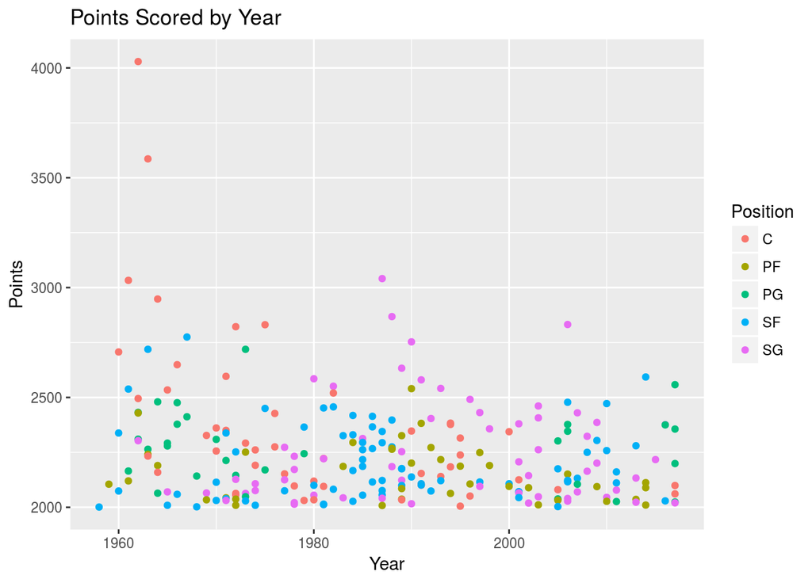

```r
points_stats %>%
  filter(Points > 2000) %>%
  ggplot(aes(x = Year , y = Points)) +
  geom_point(mapping = aes(color=Position)) +
  labs(title = "Points Scored by Year",
       x = "Year",
       y = "Points")
```

Now, I would like to shift from general points scored to three pointers scored, as the most successful teams in the modern NBA seem to successfully score three pointers in high volumes.

```r
three_pointers_stats <- nba_stats %>%
  filter(Year >= 1980) %>%
  select(Year, Player, "3P", "3P%") %>%
  rename("Three_Pointers" = "3P", "Three_Point_Percentage" = "3P%") %>%
  arrange(desc(Three_Pointers), desc(Three_Point_Percentage))
three_pointers_stats %>% slice(1:20)
```

```
## # A tibble: 20 x 4
##     Year Player           Three_Pointers Three_Point_Percentage
##    <int> <chr>                     <dbl>                  <dbl>
##  1  2016 Stephen Curry              402.                  0.454
##  2  2017 Stephen Curry              324.                  0.411
##  3  2015 Stephen Curry              286.                  0.443
##  4  2016 Klay Thompson              276.                  0.425
##  5  2013 Stephen Curry              272.                  0.453
##  6  2006 Ray Allen                  269.                  0.412
##  7  2017 Klay Thompson              268.                  0.414
##  8  1996 Dennis Scott               267.                  0.425
##  9  2017 James Harden               262.                  0.347
## 10  2014 Stephen Curry              261.                  0.424
## 11  1996 George McCloud             257.                  0.379
## 12  2017 Eric Gordon                246.                  0.372
## 13  2017 Isaiah Thomas              245.                  0.379
## 14  2008 Jason Richardson           243.                  0.406
## 15  2004 Peja Stojakovic            240.                  0.433
## 16  2017 Kemba Walker               240.                  0.399
## 17  2015 Klay Thompson              239.                  0.439
## 18  2016 James Harden               236.                  0.359
## 19  2008 Peja Stojakovic            231.                  0.441
## 20  1996 Mookie Blaylock            231.                  0.371
```

Again, incredibly, four of the top five spots in the list are held by a single player, the current point guard of the Golden State Warriors, Stephen Curry, while the other is held by his teammate, Klay Thompson. The Golden State Warriors have by far been the most dominant team in the NBA in recent years. They may very well be the greatest team in NBA history, and a large part of their success likely stems from their supreme three point shooting. It is also valuable to observe that the vast majority of these records were set recently. The three point line was introduced to the NBA in 1980, and teams are now figuring out how to use it in the most effective way possible.

This data can be better visualized with the following scatterplot comparing year to three pointers scored by each player.

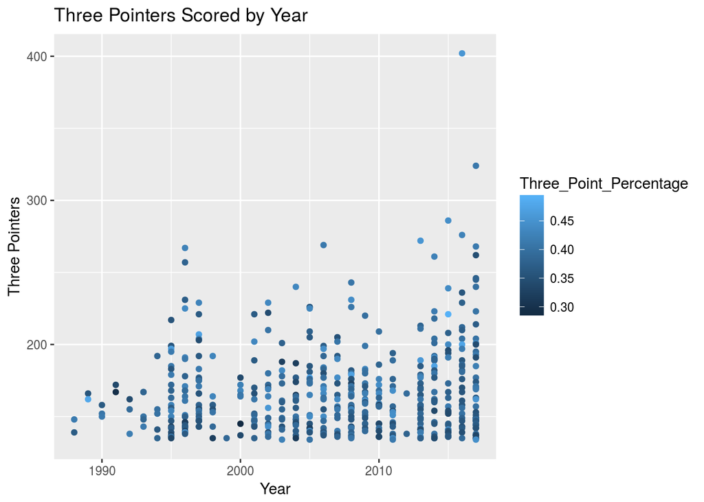

```r
three_pointers_stats %>%
  slice(1:500) %>%
  ggplot(aes(x = Year , y = Three_Pointers)) +
  geom_point(mapping = aes(color=Three_Point_Percentage)) +
  labs(title = "Three Pointers Scored by Year",
       x = "Year",
       y = "Three Pointers")
```

While scoring in high quantities is certainly impressive, this may simply be a result of taking many more shots than typical players. The greatest players of all time should be efficient, and one of the best statistical indicators of efficiency is true shooting percentage. This is based on the number of points scored with respect to the number of shots taken (giving more weight to made three pointers and less weight to free throws), and could theoretically exceed 100% if a player were to be super efficient for an entire season.

```r
ts_stats <- nba_stats %>%
  filter(PTS > 1000) %>%
  select(Year, Player, Pos, "TS%") %>%
  rename("Position" = Pos, "True_Shooting_Percentage" = "TS%") %>%
  arrange(desc(True_Shooting_Percentage))
ts_stats %>% slice(1:20)
```

```
## # A tibble: 20 x 4
##     Year Player            Position True_Shooting_Percentage
##    <int> <chr>             <chr>                       <dbl>
##  1  1982 Artis Gilmore*    C                           0.702
##  2  1981 Artis Gilmore*    C                           0.699
##  3  1973 Wilt Chamberlain* C                           0.689
##  4  2017 Rudy Gobert       C                           0.682
##  5  1985 Artis Gilmore*    C                           0.680
##  6  1980 Cedric Maxwell    SF                          0.679
##  7  1979 Cedric Maxwell    SF                          0.676
##  8  2017 DeAndre Jordan    C                           0.673
##  9  2016 Stephen Curry     PG                          0.669
## 10  1983 Artis Gilmore*    C                           0.668
## 11  1988 Charles Barkley*  PF                          0.665
## 12  1986 Artis Gilmore*    C                           0.661
## 13  1990 Charles Barkley*  SF                          0.661
## 14  1987 Charles Barkley*  PF                          0.660
## 15  2012 James Harden      SG                          0.660
## 16  2011 Nene Hilario      C                           0.657
## 17  1988 Kevin McHale*     PF                          0.656
## 18  1997 John Stockton*    PG                          0.656
## 19  2008 Amar'e Stoudemire C                           0.656
## 20  1987 Kevin McHale*     PF                          0.655
```

The vast majority of these players are big men who are able to dunk for most of their shot attempts, practically guaranteeing a high true shooting percentage. However, a few guards, particularly Stephen Curry and John Stockton, have managed to sneak onto this list as well, which is extremely impressive in its own right.

Now that I have determined some of the greatest offensive players of all time, I will do the same for defense by analyzing various key defensive statistics.

```r
rebounds_stats <- nba_stats %>%
  select(Year, Player, Pos, TRB) %>%
  rename("Position" = Pos, "Rebounds" = TRB) %>%
  arrange(desc(Rebounds))
rebounds_stats %>% slice(1:20)
```

```
## # A tibble: 20 x 4
##     Year Player            Position Rebounds
##    <int> <chr>             <chr>       <int>
##  1  1961 Wilt Chamberlain* C            2149
##  2  1962 Wilt Chamberlain* C            2052
##  3  1967 Wilt Chamberlain* C            1957
##  4  1968 Wilt Chamberlain* C            1952
##  5  1963 Wilt Chamberlain* C            1946
##  6  1966 Wilt Chamberlain* C            1943
##  7  1960 Wilt Chamberlain* C            1941
##  8  1964 Bill Russell*     C            1930
##  9  1965 Bill Russell*     C            1878
## 10  1961 Bill Russell*     C            1868
## 11  1963 Bill Russell*     C            1843
## 12  1962 Bill Russell*     C            1790
## 13  1964 Wilt Chamberlain* C            1787
## 14  1966 Bill Russell*     C            1779
## 15  1960 Bill Russell*     C            1778
## 16  1969 Wilt Chamberlain* C            1712
## 17  1967 Bill Russell*     C            1700
## 18  1965 Wilt Chamberlain* C            1673
## 19  1966 Jerry Lucas*      PF           1668
## 20  1959 Bill Russell*     C            1612
```

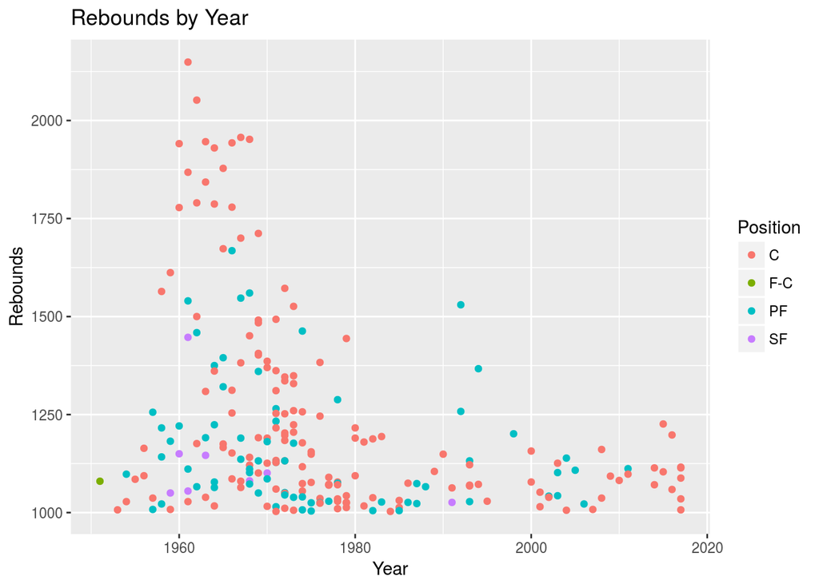

```r
rebounds_stats %>%
  filter(Rebounds > 1000) %>%
  ggplot(aes(x = Year , y = Rebounds)) +
  geom_point(mapping = aes(color=Position)) +
  labs(title = "Rebounds by Year",
       x = "Year",
       y = "Rebounds")
```

```r
blocks_stats <- nba_stats %>%
  select(Year, Player, Pos, BLK) %>%
  rename("Position" = Pos, "Blocks" = BLK) %>%
  arrange(desc(Blocks))
blocks_stats %>% slice(1:20)
```

```
## # A tibble: 20 x 4
##     Year Player               Position Blocks
##    <int> <chr>                <chr>     <dbl>
##  1  1985 Mark Eaton           C          456.
##  2  1986 Manute Bol           C          397.
##  3  1974 Elmore Smith         C          393.
##  4  1990 Hakeem Olajuwon*     C          376.
##  5  1986 Mark Eaton           C          369.
##  6  1984 Mark Eaton           C          351.
##  7  1989 Manute Bol           C          345.
##  8  1983 Tree Rollins         C          343.
##  9  1993 Hakeem Olajuwon*     C          342.
## 10  1976 Kareem Abdul-Jabbar* C          338.
## 11  1994 Dikembe Mutombo*     C          336.
## 12  1996 Dikembe Mutombo*     C          332.
## 13  1990 Patrick Ewing*       C          327.
## 14  1987 Mark Eaton           C          321.
## 15  1995 Dikembe Mutombo*     C          321.
## 16  1991 David Robinson*      C          320.
## 17  1990 David Robinson*      C          319.
## 18  1979 Kareem Abdul-Jabbar* C          316.
## 19  1989 Mark Eaton           C          315.
## 20  2004 Theo Ratliff         C          307.
```

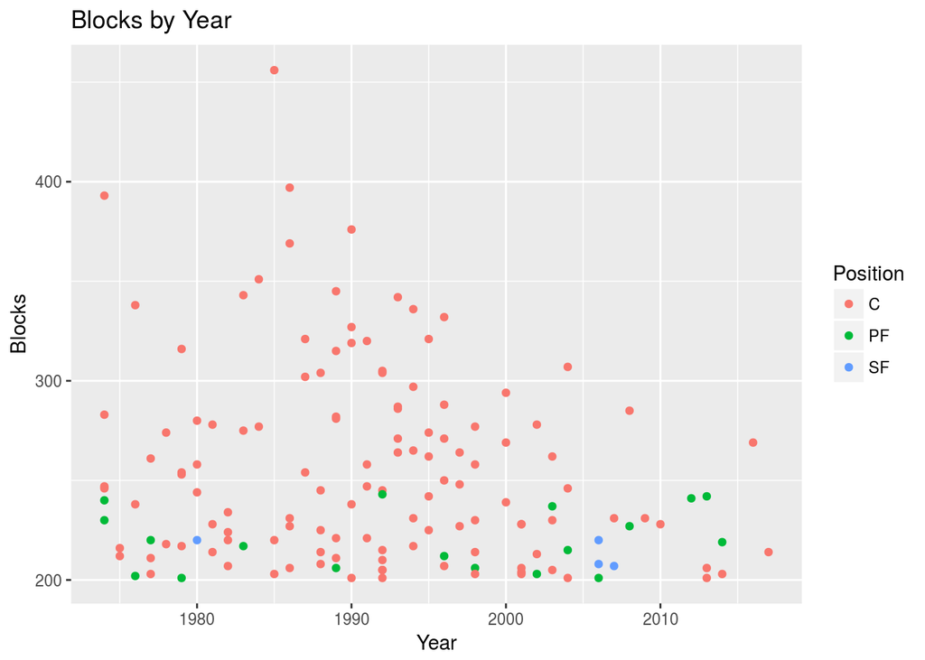

```r
blocks_stats %>%
  filter(Blocks > 200) %>%
  ggplot(aes(x = Year , y = Blocks)) +
  geom_point(mapping = aes(color=Position)) +
  labs(title = "Blocks by Year",
       x = "Year",
       y = "Blocks")
```

```r
steals_stats <- nba_stats %>%
  select(Year, Player, Pos, STL) %>%
  rename("Position" = Pos, "Steals" = STL) %>%
  arrange(desc(Steals))
steals_stats %>% slice(1:20)
```

```
## # A tibble: 20 x 4
##     Year Player           Position Steals
##    <int> <chr>            <chr>     <dbl>
##  1  1986 Alvin Robertson  SG         301.
##  2  1977 Don Buse         PG         281.
##  3  1980 Micheal Ray      SG         265.
##  4  1989 John Stockton*   PG         263.
##  5  1976 Slick Watts      PG         261.
##  6  1987 Alvin Robertson  SG         260.
##  7  1988 Michael Jordan*  SG         259.
##  8  1991 Alvin Robertson  SG         246.
##  9  1992 John Stockton*   PG         244.
## 10  1985 Micheal Ray      PG         243.
## 11  1988 Alvin Robertson  SG         243.
## 12  1988 John Stockton*   PG         242.
## 13  1987 Michael Jordan*  SG         236.
## 14  1989 Michael Jordan*  SG         234.
## 15  1991 John Stockton*   PG         234.
## 16  1992 Micheal Williams PG         233.
## 17  1981 Micheal Ray      SG         232.
## 18  1995 Scottie Pippen*  SF         232.
## 19  1996 Gary Payton*     PG         231.
## 20  1985 Johnny Moore     PG         229.
```

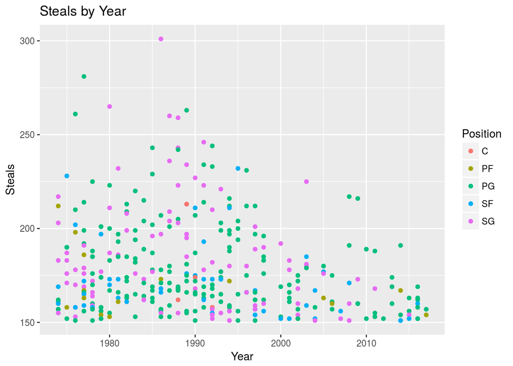

```r
steals_stats %>%
  filter(Steals > 150) %>%
  ggplot(aes(x = Year , y = Steals)) +
  geom_point(mapping = aes(color=Position)) +
  labs(title = "Steals by Year",
       x = "Year",
       y = "Steals")
```

Based on this analysis, some notable defensive names include Wilt Chamberlain, Bill Russell, Mark Eaton, and Michael Jordan. By being dominant on both the offensive and defensive ends of the court, Wilt Chamberlain and Michael Jordan have practically sealed themselves in as two of the greatest NBA players of all time.

### Hypothesis Testing

Now, I would like to test one of the suspicions that I developed while analyzing the NBA player data. Is it true that as time has passed, the style of play that NBA teams tend to follow has changed, with the average number of three point shots taken by teams increasing? I will determine this by comparing the average number of three point shot attempts by teams in the NBA in 1997 with the same statistic in 2017.

In order to conduct this test, I must first reorganize the data so that I can easily attain my desired values.

```r
three_point_attempts_stats <- nba_stats %>%
  filter(Year >= 1980) %>%
  select(Year, Tm, "3PA") %>%
  rename("Team" = Tm, "Three_Point_Attempts" = "3PA") %>%
  group_by(Year, Team) %>%
  summarise(Three_Point_Attempts = sum(Three_Point_Attempts)) %>%
  group_by(Year) %>%
  summarise(Mean_3PA = mean(Three_Point_Attempts), SD_3PA = sd(Three_Point_Attempts))
three_point_attempts_stats %>% slice(1:20)
```

```
## # A tibble: 20 x 3
##     Year Mean_3PA SD_3PA
##    <int>    <dbl>  <dbl>
##  1  1980     240.  127.
##  2  1981     173.   81.9
##  3  1982     194.   74.4
##  4  1983     191.   65.4
##  5  1984     192.   63.3
##  6  1985     250.   85.5
##  7  1986     278.   96.3
##  8  1987     382.  119.
##  9  1988     447.  229.
## 10  1989     558.  228.
## 11  1990     549.  187.
## 12  1991     592.  211.
## 13  1992     623.  188.
## 14  1993     728.  209.
## 15  1994     823.  202.
## 16  1995    1281.  269.
## 17  1996    1384.  466.
## 18  1997    1467.  553.
## 19  1998    1134.  569.
## 20  1999     675.  178.
```

The desired values are: 1997 - Mean_3PA = 1467.03, SD_3PA = 553.39 2017 - Mean_3PA = 2359.23, SD_3PA = 873.34

Next, I will conduct a hypothesis on the difference between the two population means.

$H_0: 3PA_{2017}-3PA_{1997}=0$  
$H_A: 3PA_{2017}-3PA_{1997}>0$

```r
p_value <- 1 - pnorm(2359.23-1467.03, mean = 0, sd = sqrt((873.34^2+553.39^2)/30))
print(p_value)
```

```
## [1] 1.142004e-06
```

As the p_value < .01, we reject $H_0$ and conclude that the number of three point shots attempted by teams increased from 1997 to 2017. This change in playstyle is logical, as teams are able to score more points from the same number of posessions by successfully making three point shots, assuming that players are able to do so reliably. Today, Stephen Curry is hailed as being the greatest shooter in history, frequently draining well over 90% of his attempts in practice, a skill that requires defenders to guard him very closely. It is safe to say that he is another of the greatest NBA players of all time.

### Machine Learning

I would like to see if the increase in average number of three point shots attempted by teams in each year of the NBA follows a roughly linear trend.

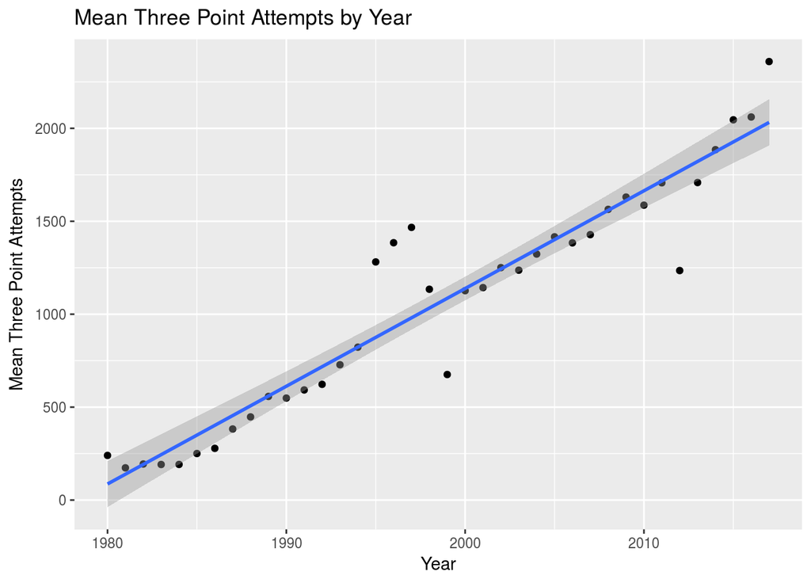

```r
three_point_attempts_stats %>%
  ggplot(aes(x = Year , y = Mean_3PA)) +
  geom_point() +
  geom_smooth(method = lm) +
  labs(title = "Mean Three Point Attempts by Year",
       x = "Year",
       y = "Mean Three Point Attempts")
```

The graph can be described by the following regression model.

```r
three_point_attempts_fit <- lm(Mean_3PA~Year, data=three_point_attempts_stats)
three_point_attempts_fit %>%
  tidy()
```

```
##          term      estimate   std.error statistic      p.value
## 1 (Intercept) -104026.00776 5686.965825 -18.29201 8.221346e-20
## 2        Year      52.58208    2.845574  18.47855 5.904419e-20
```

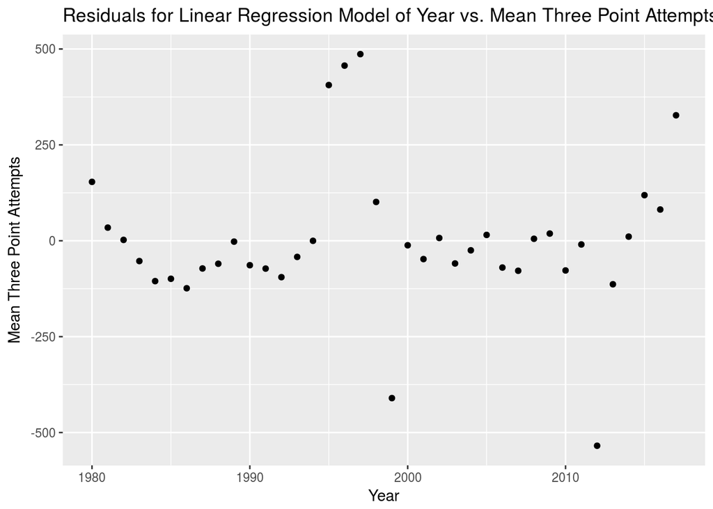

```r
augmented_three_point_attempts <- three_point_attempts_fit %>%
  augment()

augmented_three_point_attempts %>%
  ggplot(aes(x = Year, y = .resid)) +
    geom_point() +
    labs(title = "Residuals for Linear Regression Model of Year vs. Mean Three Point Attempts",
         x = "Year",
         y = "Mean Three Point Attempts")
```

### Closing

With that, I have completed my basic tutorial of the data science pipeline. I hope that you have learned about data curation, parsing, and management, exploratory data analysis, hypothesis testing, and machine learning. I highly recommend that you use what you have learned to conduct your own data analysis, whether it be based around the NBA, or some other topic that catches your interest. Best wishes!

### References

Data Curation, Parsing, and Management: https://conferences.oreilly.com/strata/stratany2014/public/schedule/detail/36021  
Exploratory Data Analysis: https://www.itl.nist.gov/div898/handbook/eda/eda_d.htm  
Hypothesis Testing: http://www.statisticshowto.com/probability-and-statistics/hypothesis-testing/  
Machine Learning: https://www.mathworks.com/discovery/machine-learning.html